## Laplace diagnostics

Version: 2014-12-29 21:17:10

This document reproduces and extends the procedures originally invented by Doug Bates (currently part of a draft paper on GLMMs in `lme4`) to visualize the likelihood profiles of individual conditional modes (random effects parameters for individual groups) in GLMM. In particular, this visualization gives a useful way to understand the accuracy of Laplace and Gauss-Hermite quadrature approximations.

```r
library("lme4")
library("lattice")
library("ggplot2"); theme_set(theme_bw())
library("plyr")      ## for reshaping
library("abind")     ## ditto
library("reshape2")  ## for melt() generic
library("bbmle")     ## for AICtab
```

Replicate glmer paper Figs 2/3: these graphs show first the likelihood profiles for the individual conditional modes, then the likelihood profiles scaled by the standard Normal. If the likelihood profiles are proportional to $N(0,1)$, the Laplace approximation will be adequate; if the likelihood profiles are proportional to $f_n(x) \exp(-x^2)$, where $f_n$ is an $n^\textrm{th}$-order polynomial, then an AGHQ fit with $n-1$ quadrature points will be adequate.

The CBPP data are actually pretty boring (if you’re looking for deviations):

```r
m1 <- glmer(cbind(incidence, size-incidence) ~ period + (1|herd),
                  cbpp, binomial)
m1.z <- zeta(m1)
```

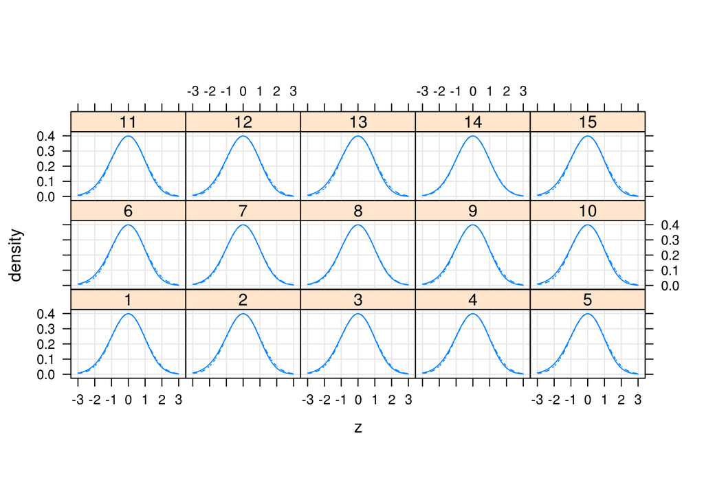

```r
plot(m1.z,layout=c(5,3))
```

The standardized plots make it easier to see the deviations:

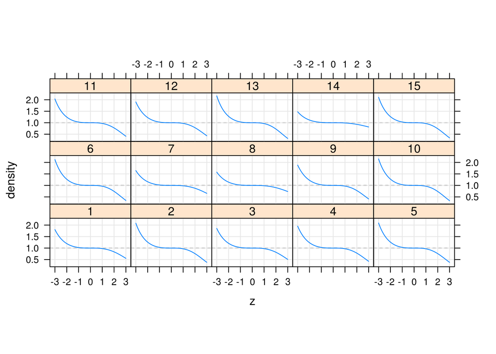

```r
plot(m1.z,scaled=TRUE,layout=c(5,3))
```

### Toenail data example

The toenail data are much more poorly behaved (presumably? due to smaller total numbers of observations per group):

```r
toenail <- read.csv("toenail.csv")
m2 <- glmer(outcome~treatment*visit+(1|patient),toenail,
            family=binomial)
```

Since there are 294 groups, it will be awkward to plot them all – we’ll look at a subset (**to do**: sort groups by degree of non-Normality)

```r
m2.z <- zeta(m2,grps=1:36)
```

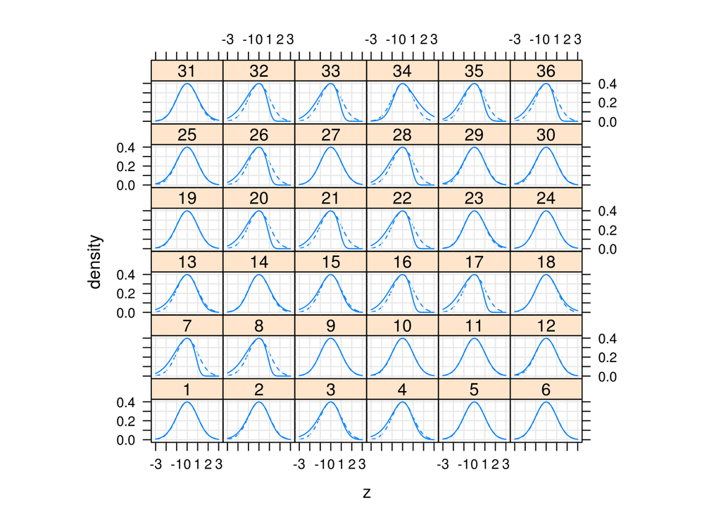

```r
plot(m2.z)
```

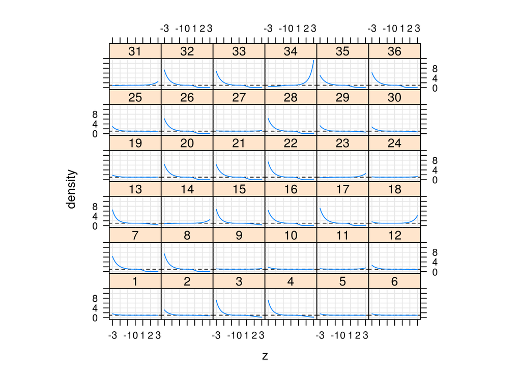

```r
plot(m2.z,scaled=TRUE)
```

### Example with vector-valued RE

Try a random-slopes model:

```r
m3 <- glmer(outcome~treatment*visit+(visit|patient),toenail,
            family=binomial,
            control=glmerControl(optimizer="bobyqa"))
```

The data *strongly* support a random-slopes model:

```r
AICtab(m2,m3)
```

```
##    dAIC  df
## m3   0.0 7
## m2 283.3 5
```

```r
m3.z <- zeta(m3,grps=1:25)
```

This is a nice collection of mussels …

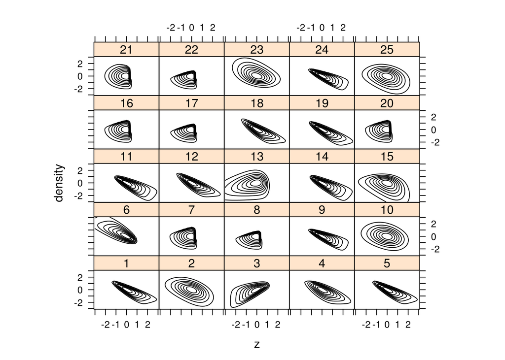

```r
plot(m3.z)
```

Still trying to work out the analogue of Figure 3 (i.e., a version where we scale by the bivariate normal). I think this actually *should* work, but this example is very badly behaved in the corner …

Just look at patient #1 to try to sort out what’s going on here …

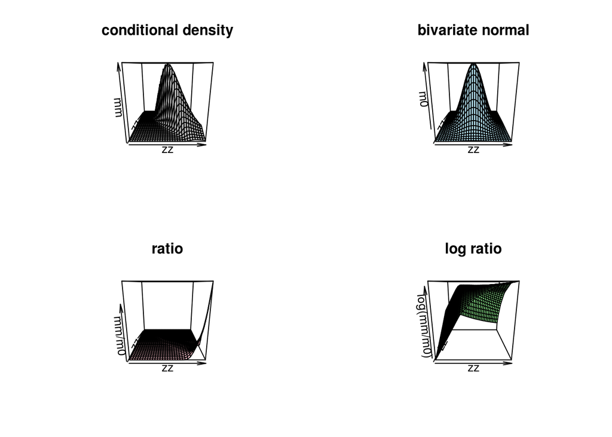

```r
zz <- m3.z$zvals
mm <- 2*pi*dnorm2d(sqrt(m3.z$devarr[,,1]))
m0 <- 2*pi*dnorm2d(sqrt(outer(zz^2,zz^2,"+")))
par(mfrow=c(2,2))
persp(zz,zz,mm,col="gray",main="conditional density")
persp(zz,zz,m0,col="lightblue",main="bivariate normal")
persp(zz,zz,mm/m0,col="pink",main="ratio")
persp(zz,zz,log(mm/m0),col="lightgreen",main="log ratio")
```

Does this really matter, or are we only in trouble if we put quadrature points there?

### Further thoughts

How do we actually put GHQ into practice based on this information? Can we come up with a sort of a score statistic for GHQ (i.e., what would the difference be in log-likehood *conditional on parameters* for different numbers of quadrature points)?

Check that `GHrule` and `GQdk` are equivalent (they’re based on the same underlying code, so they should be!)

```r
(gh5 <- GHrule(5))
```

```
##                  z          w     ldnorm
## [1,] -2.856970e+00 0.01125741 -5.0000774
## [2,] -1.355626e+00 0.22207592 -1.8377997
## [3,]  3.865099e-17 0.53333333 -0.9189385
## [4,]  1.355626e+00 0.22207592 -1.8377997
## [5,]  2.856970e+00 0.01125741 -5.0000774
```

```r
gh5B <- GQdk(1,5)
gh5B <- gh5B[order(gh5B[,2]),]
all.equal(gh5B[,2:1],unname(gh5[,-3]))
```

```
## [1] TRUE
```

Can we do some simple calculations with `GHrule` and the `zeta` values to reconstruct the 1-D Gauss-Hermite results and convince ourselves we’re getting the same results as from `glmerAGQ` ?

```r
zd <- zetaDevfun(m1)
z2A <- zeta(m1,zvals=gh5[,"z"])
z2 <- t(sapply(gh5[,"z"],zd))
z2B <- sweep(z2,2,zd(0),"-")
all.equal(unname(z2A$devarr),z2B)
```

```
## [1] TRUE
```

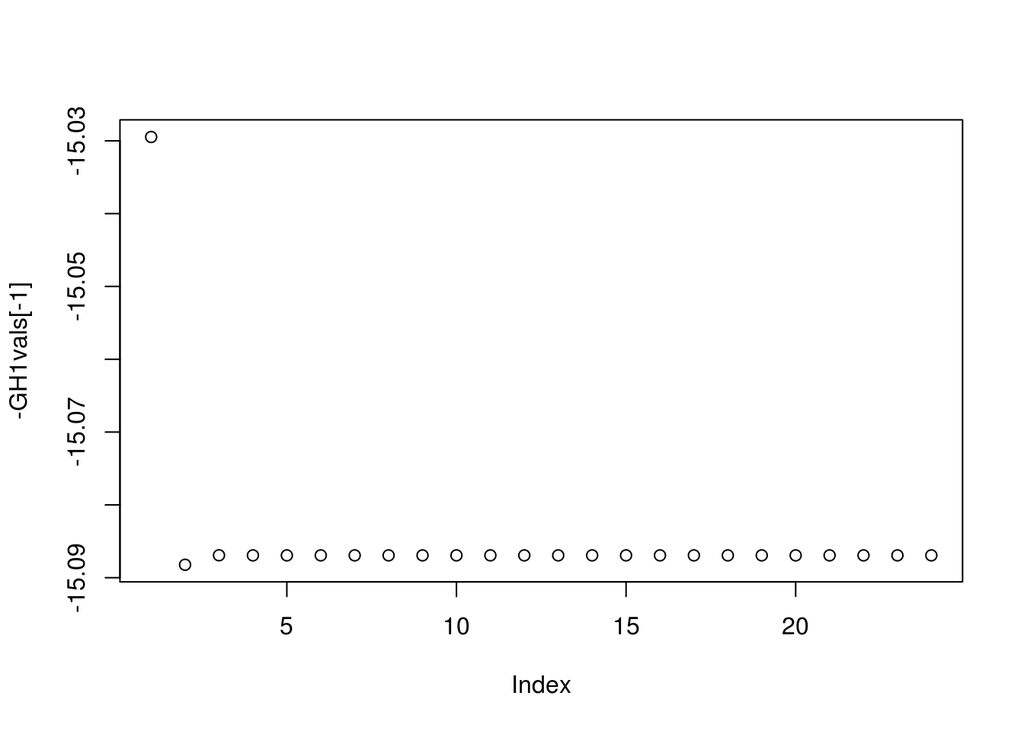

```r
GH1d <- function(m,nAGQ=2) {
    gh <- GHrule(nAGQ)
    z <- zeta(m,zvals=gh[,"z"])
    sum(rowSums(z$devarr)*gh[,"w"])
}
GH1vals <- sapply(1:25,GH1d,m=m1)
plot(-GH1vals[-1])
```

```r
m1GHvec <- sapply(2:25,
                  function(q) {
                      deviance(update(m1,nAGQ=q))
                  })
m1GHvec2 <- sapply(2:25,
                  function(q) {
                      dd <- update(m1,devFunOnly=TRUE,nAGQ=q)
                      dd(unlist(getME(m1,c("theta","fixef"))))
                  })
```

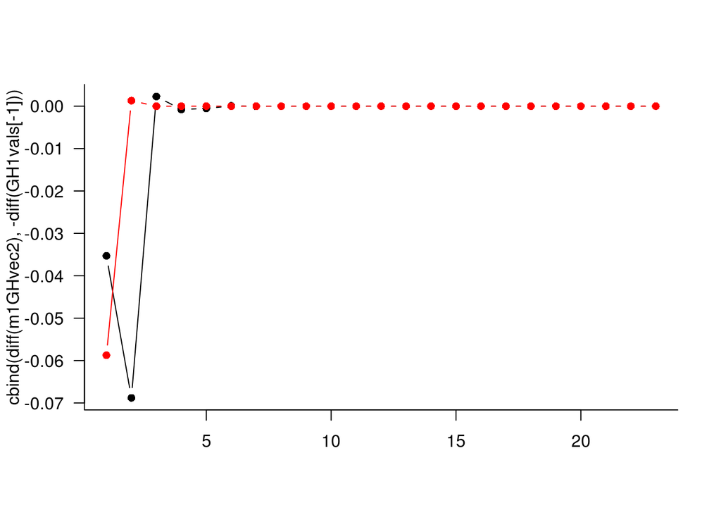

```r
par(las=1,bty="l")
matplot(cbind(diff(m1GHvec2),-diff(GH1vals[-1])),
        type="b",pch=16,lty=1)
```

These patterns don’t match … but we don’t necessarily expect them to match, as the hand-rolled comparison keeps theta, beta, *and the conditional modes* fixed, while using the deviance function updates the conditional modes (I think …)

Toenail data from [here](http://tigger.uic.edu/~hedeker/long.html).